# P4: Explore and Sumarize Data

# Univariate Plots Section

> In this section, you should perform some preliminary exploration of your dataset. Run some summaries of the data and create univariate plots to understand the structure of the individual variables in your dataset. Don’t forget to add a comment after each plot or closely-related group of plots! There should be multiple code chunks and text sections; the first one below is just to help you get started.

We will start showing one of the most important features, which is the quality of the wine. With this plot we weill have an idea about what is the most common quality in wines.

```
## pf$quality: 3
## [1] 0.997565
## --------------------------------------------------------
## pf$quality: 4
## [1] 0.9965
## --------------------------------------------------------
## pf$quality: 5
## [1] 0.997
## --------------------------------------------------------
## pf$quality: 6
## [1] 0.99656
## --------------------------------------------------------
## pf$quality: 7
## [1] 0.99577
## --------------------------------------------------------
## pf$quality: 8
## [1] 0.99494
```

```
## pf$quality: 3
## [1] 9.925
## --------------------------------------------------------
## pf$quality: 4
## [1] 10
## --------------------------------------------------------
## pf$quality: 5
## [1] 9.7
## --------------------------------------------------------
## pf$quality: 6
## [1] 10.5
## --------------------------------------------------------
## pf$quality: 7
## [1] 11.5
## --------------------------------------------------------
## pf$quality: 8
## [1] 12.15
```

```
## pf$quality: 3
## [1] 3.39
## --------------------------------------------------------
## pf$quality: 4
## [1] 3.37
## --------------------------------------------------------
## pf$quality: 5
## [1] 3.3
## --------------------------------------------------------
## pf$quality: 6
## [1] 3.32
## --------------------------------------------------------
## pf$quality: 7
## [1] 3.28
## --------------------------------------------------------
## pf$quality: 8
## [1] 3.23
```

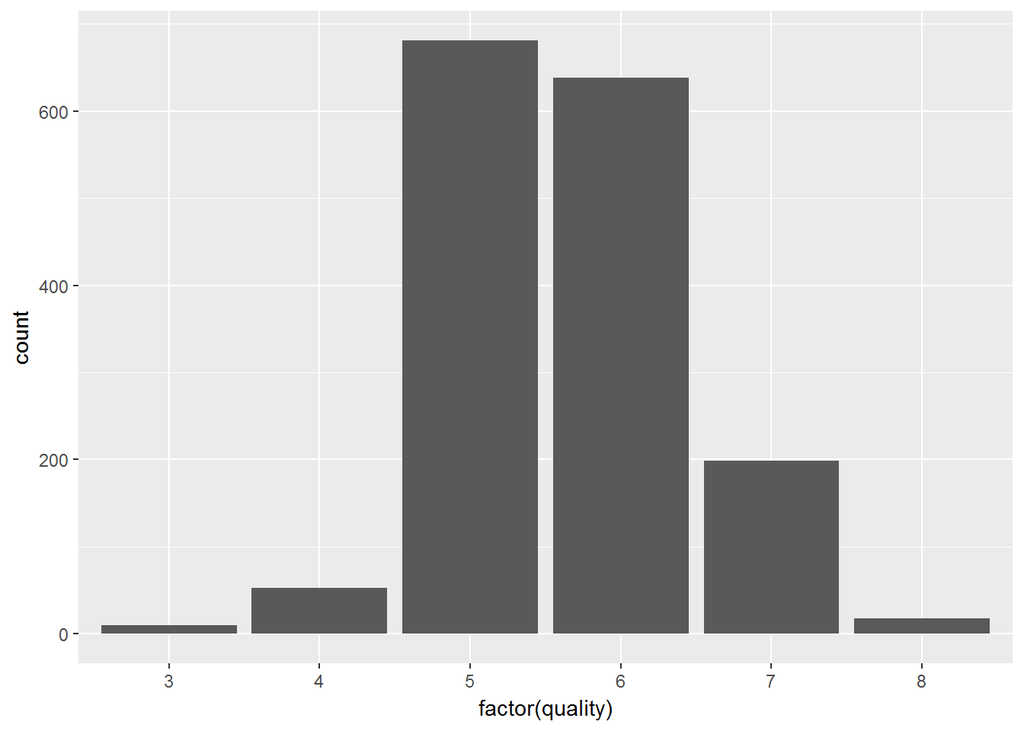

Histograms

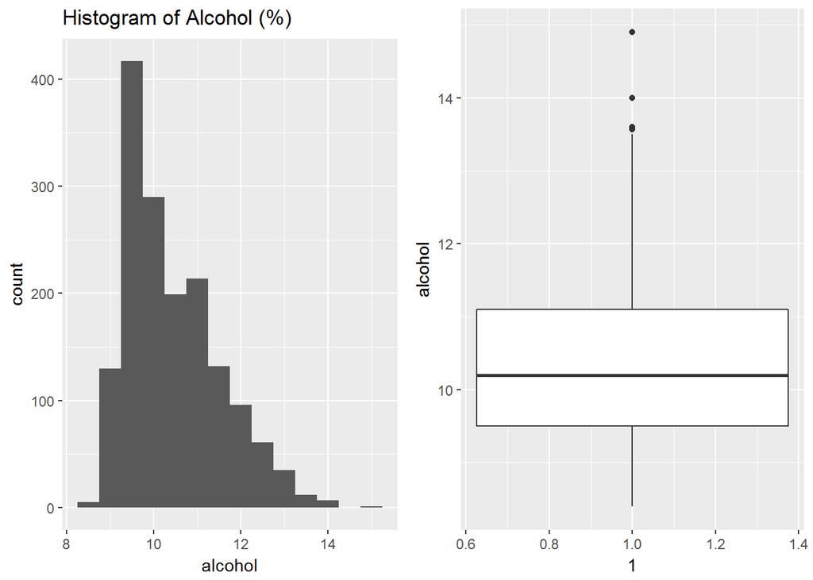

```
##    Min. 1st Qu.  Median    Mean 3rd Qu.    Max.
##    8.40    9.50   10.20   10.42   11.10   14.90
```

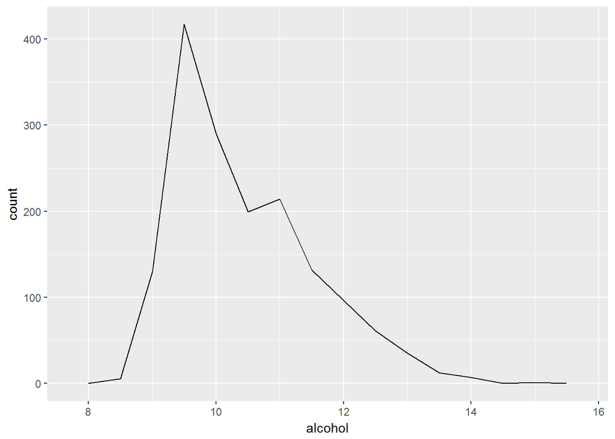

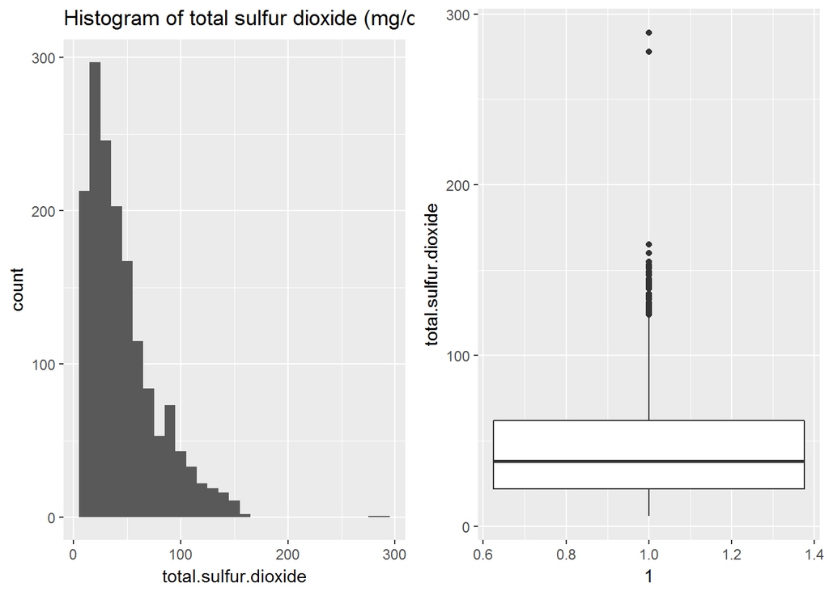

```
##    Min. 1st Qu.  Median    Mean 3rd Qu.    Max.
##    6.00   22.00   38.00   46.47   62.00  289.00
```

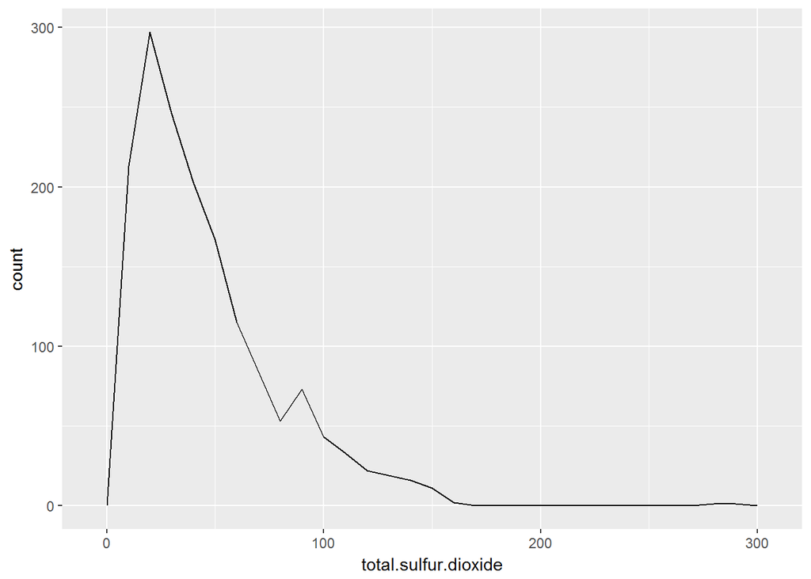

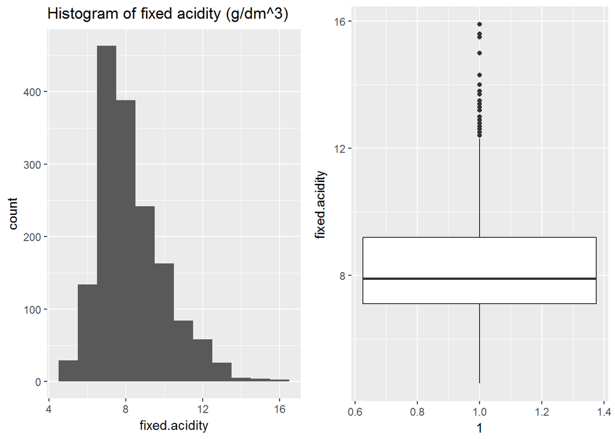

```
##    Min. 1st Qu.  Median    Mean 3rd Qu.    Max.
##    4.60    7.10    7.90    8.32    9.20   15.90
```

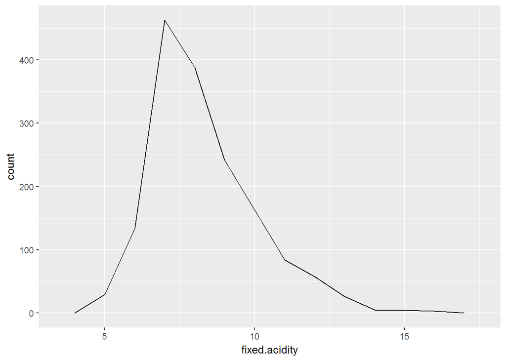

We can see the fixed acidity is a right skewed graphic concentred in 7. We can see multiple outliers. Fixed acidity has a similar distribution as the other features with its peak at 7g/dm3.

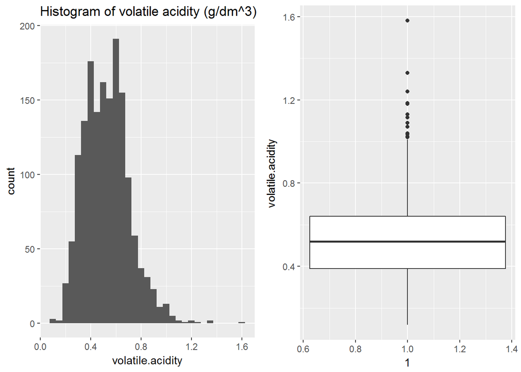

```
##    Min. 1st Qu.  Median    Mean 3rd Qu.    Max.
##  0.1200  0.3900  0.5200  0.5278  0.6400  1.5800
```

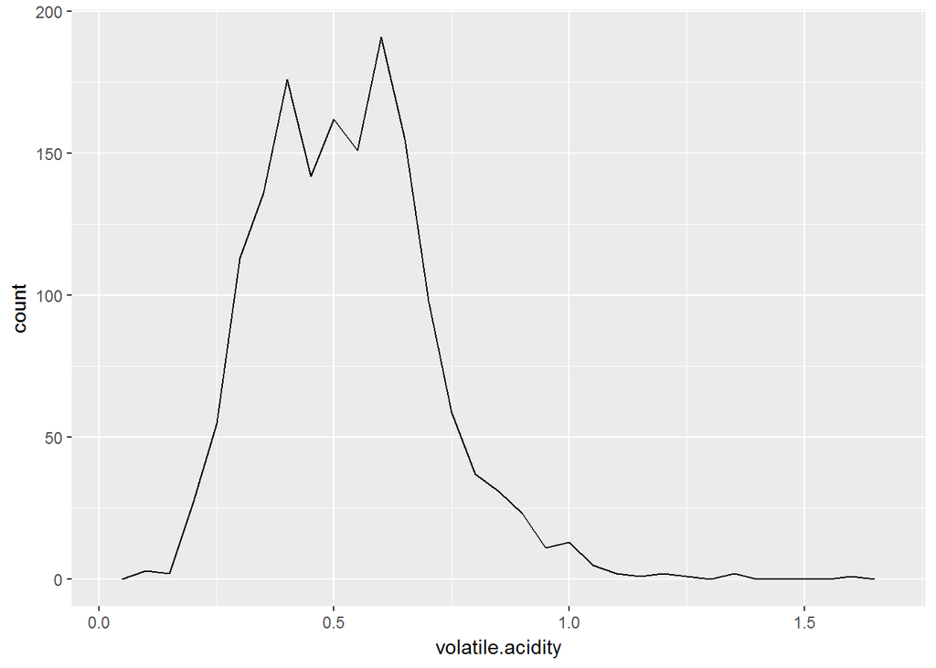

The distribution of volatile acidity is a bimodal right skewed, concentred in 0.35 and 0.6. There are a few outliers. Volatile acidity has a similar distribution as the other features, however volatile acidity has a broad peak between 0.4 and 0.7 g/dm3.

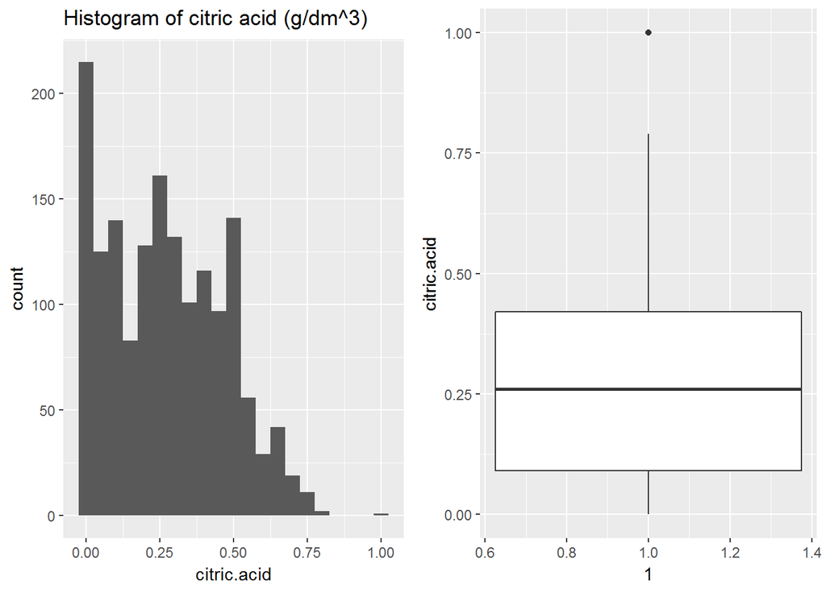

```
##    Min. 1st Qu.  Median    Mean 3rd Qu.    Max.
##   0.000   0.090   0.260   0.271   0.420   1.000
```

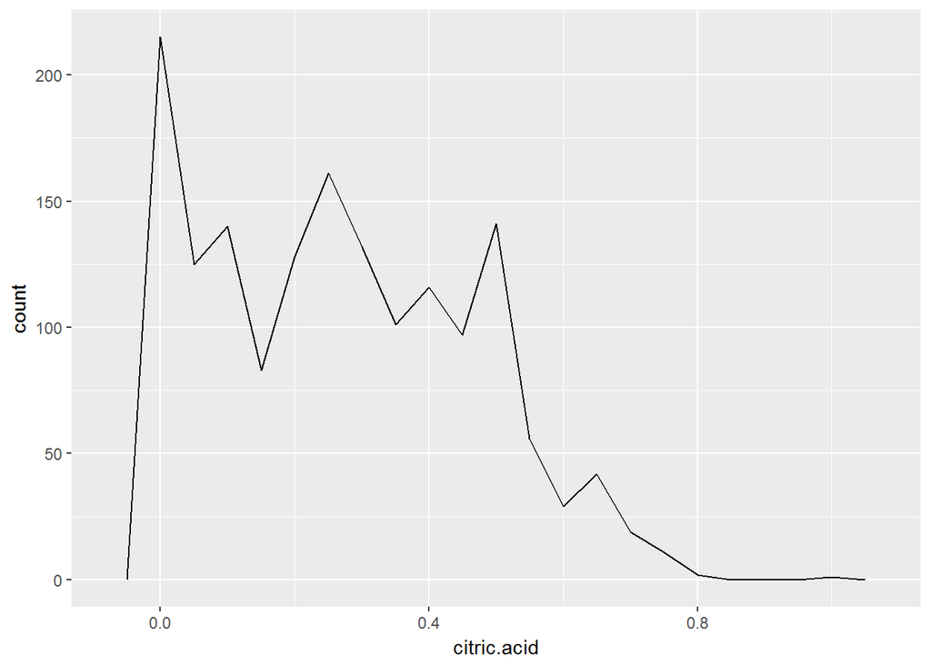

Citrid Acid is a not normal distribution. Only an outlier. It doesn’t seem to be a common citrid acid for the wines in the data set.

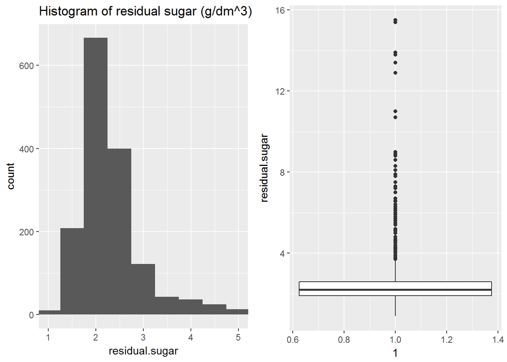

```
##    Min. 1st Qu.  Median    Mean 3rd Qu.    Max.
##   0.900   1.900   2.200   2.539   2.600  15.500
```

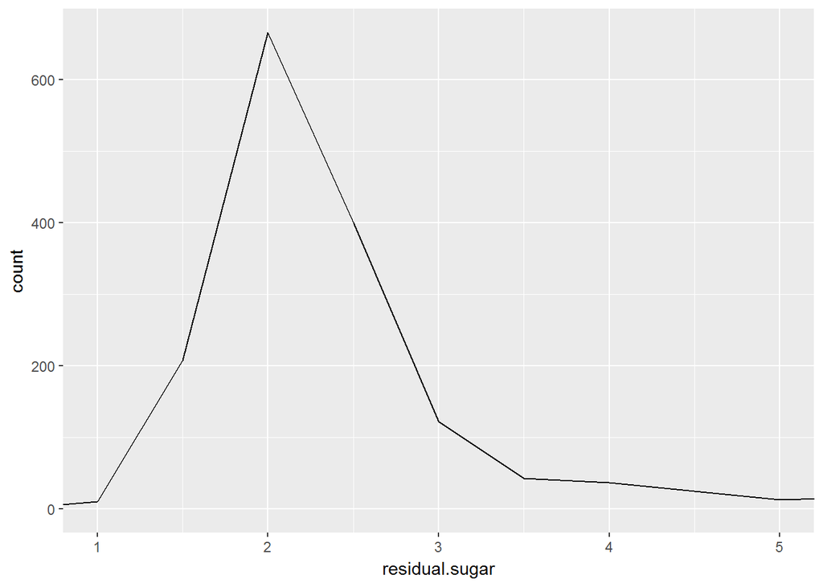

Several outliers. As most of the features, it is a right skewed distribution concentrated in 2 g/dm3.

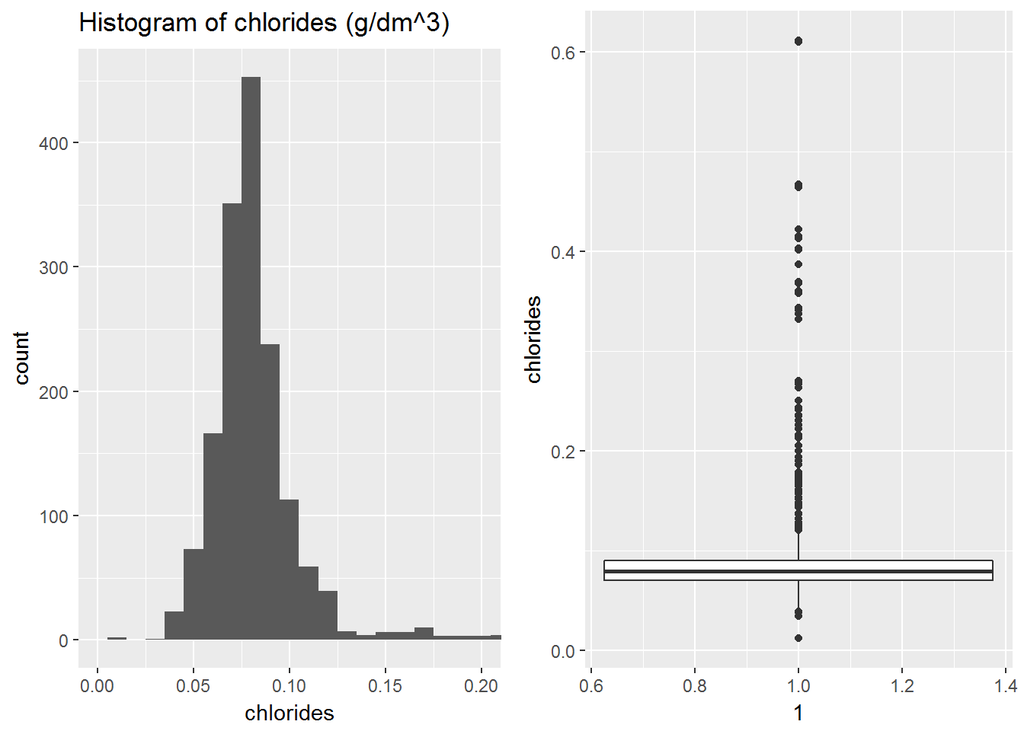

```
##    Min. 1st Qu.  Median    Mean 3rd Qu.    Max.
## 0.01200 0.07000 0.07900 0.08747 0.09000 0.61100
```

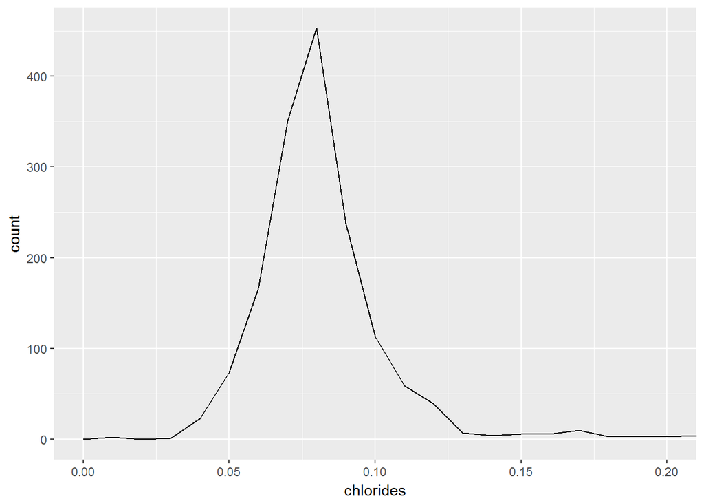

Chloricles is right skewed distribution as well, concentrated in 0.08. Several outliers. Chloricles has a similar distribution as the other features with its peak at 0.08 g/dm3.

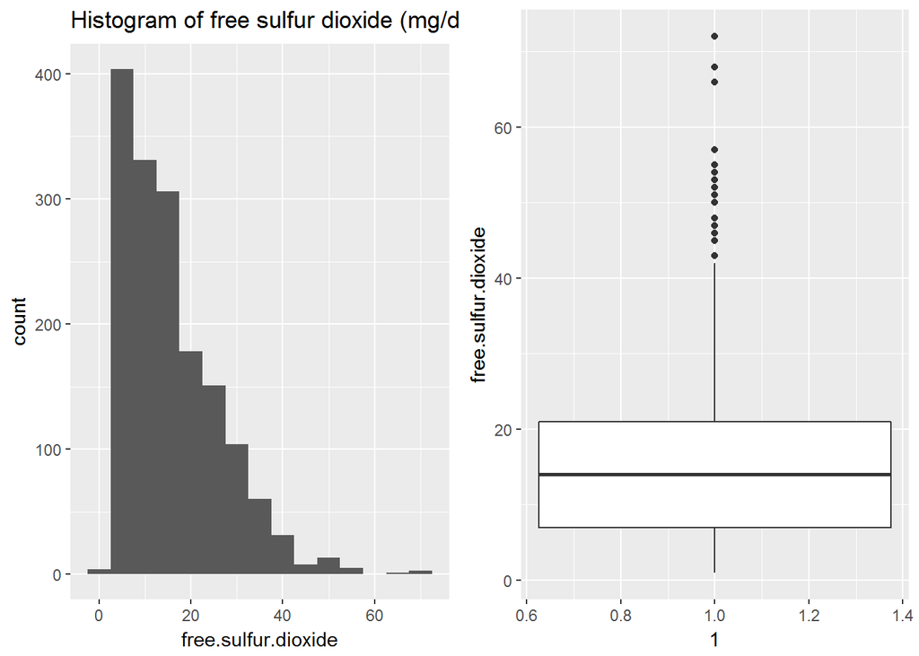

```
##    Min. 1st Qu.  Median    Mean 3rd Qu.    Max.
##    1.00    7.00   14.00   15.87   21.00   72.00
```

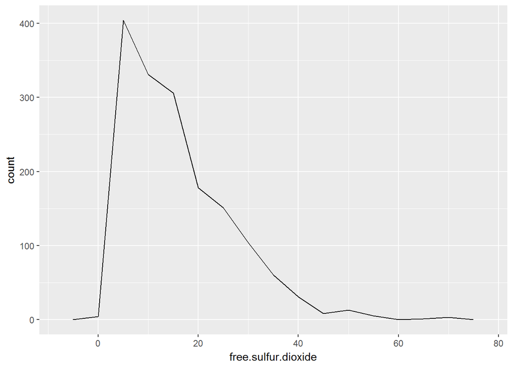

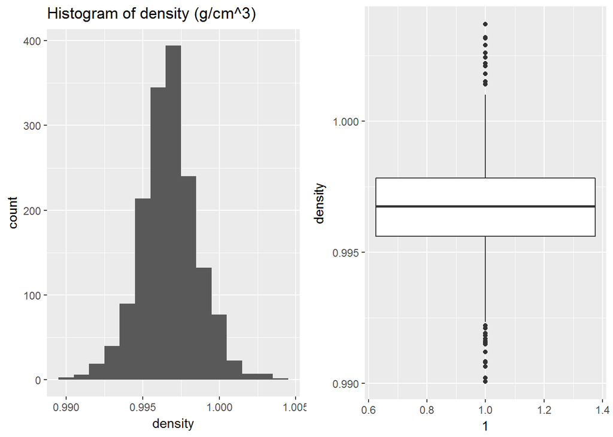

```
##    Min. 1st Qu.  Median    Mean 3rd Qu.    Max.
##  0.9901  0.9956  0.9968  0.9967  0.9978  1.0040
```